# ggHorizon

Zuzanna_Pirog

2022-12-29

## Wstęp

Niniejsza praca stanowi rozwiązanie zadania domowego nr 6 z przedmiotu Techniki Wizualizacji Danych. Celem zadania było opisanie i zaprezentowanie jednej z nieomawaianej w czasie zajęć biblioteki. Ja skupiłam się na pakiecie **ggHoriPlot**. Przy poszukiwaniu materiałów korzystałam głównie ze strony https://rviews.rstudio.com/.

## Pakiet ggHoriPlot

Omawiany pakiet **ggHoriPlot** współpracuje z pakietem **ggplot2** i umożliwia w łatwy sposób tworzenie wykresów horyzontalnych, czyli warstwowych. Wykresy warstwowe, to szczególne wykresy, dzięki którym na niewielkiej powierzchni jesteśmy w stanie przekazać wiele informacji za pomocą koloru. Wykorzystuje się go głównie do wizualizacji danych, które zachodziły na danym okresie czasu i pokazuje zależności między nimi, np intensywność danego zdarzenia. Warto zwrócić uwagę, że warstwy dodatnie i ujemne rysowane są na tym samym poziomie, dodatkowo wykres składa się z kilku “pięter”, które są na siebie nałożone, każda kolejna warstwa powowduje coraz większą intensywność koloru.

Pakiet **ggHoriPlot** to pakiet przeznaczony do pracy z językiem R, a ściślej to pewnego rodzaju rozszerzenie znanego nam pakietu **ggplot2**. Stąd też przy tworzeniu wykresu, parametry, które możemy ustalić okazują się analogiczne jak w podstawowym **ggplot2**. To, co wyróżnia ten pakiet to opcja ustawiania osi startowej pod nazwą **origin**, od której decydujemy co jest “dodadatnie” a co “ujemne” na wykresie warstwowym (mamy możliwość wyboru wartości minimalnej, średniej, mediany i wiele innych) oraz **horizonscale**, które mówi o przysłowiowej liczbie “pięter” na jakie ma być podzielony nasz wykres. Jeżeli chcemy możemy również odwrócić wartości(horizon peaks) przy pomocy parametru **mirror**.

## Wizualizacja

Poniżej przedstawiłam wiualizację na podstawie ramki danych, jaka staje się dla nas dostępna po pobraniu omawianego pakietu. Chodzi tu o ramkę danych zawierającą geograficzną dystrybucję zachorowań na COVID-19 w Azji w 2020 roku. Przy pomocy pakietu **ggHoriPlot** jesteśmy w stanie określić ile było fal zachorowań i w jakim czasie, dla danego kraju i porównać te zależności. Kod jest intuicyjny i łatwy w zrozumieniu

```r
library(ggthemes)
library(ggHoriPlot)
library(dplyr)
```

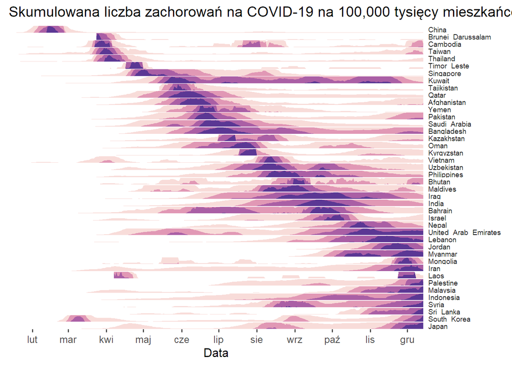

```r
utils::data(COVID)

COVID %>%
  ggplot()+ #wspomniane środowisko ggplot2
  geom_horizon(aes(x = date_mine, y = y),
               origin = "min",
               horizonscale = 4) +
  scale_fill_hcl(palette = 'Purple-Orange', reverse = T) +
  facet_grid(countriesAndTerritories~.) + #podział na kraje na jednym wykresie
  theme_few()+
  theme(panel.spacing.y = unit(0, "lines"),
        strip.text.y = element_text(size = 7, angle = 0, hjust = 0),
        legend.position = 'none',
        axis.text.y = element_blank(),
        axis.title.y = element_blank(),
        axis.ticks.y = element_blank(),
        panel.border = element_blank())+
  scale_x_date(expand = c(0,0), date_breaks = "1 month", date_labels = "%b")+
  ggtitle('Skumulowana liczba zachorowań na COVID-19 na 100,000 tysięcy mieszkańców w Azji w przeciągu 14 dni w 2020')+
  xlab("Data")
```

## Podsumowanie

Pakiet **ggHoriPlot** okazuje się być niezwykle przydatny w wizualiazacji określonych dypów danych. Sam pakiet zaciekawił mnie ponieważ do tej pory nie miałam styczności z wykresami warstowymi. Uważam, że omawiany pakiet jest warty uwagi i zdecydowanie wykorzystam go w przyszłości.